# Estimation of STABILIZED weights for covariate balance

Denis Shah

27 January, 2024

# 1 Scalar sample balance statistics

|  | Method | smd | ovl | mahalanobis | kernel | energy |
| --- | --- | --- | --- | --- | --- | --- |
| 1 | unweighted | 0.098 | 0.044 | 0.752 | 0.046 | 0.102 |
| 2 | GLM | 0.017 | 0.016 | 0.163 | 0.049 | 0.018 |
| 3 | BRGLM | 0.016 | 0.016 | 0.155 | 0.048 | 0.018 |
| 4 | GBM | 0.046 | 0.023 | 0.482 | 0.047 | 0.034 |
| 5 | GBMT | 0.046 | 0.023 | 0.481 | 0.047 | 0.034 |
| 6 | CBPS | 0.022 | 0.018 | 0.229 | 0.047 | 0.020 |
| 7 | EBAL | 0.000 | 0.012 | 0.001 | 0.049 | 0.016 |
| 8 | OPTWT | 0.000 | 0.012 | 0.000 | 0.049 | 0.016 |
| 9 | SL | 0.027 | 0.017 | 0.329 | 0.049 | 0.024 |
| 10 | SLMB | 0.017 | 0.015 | 0.193 | 0.048 | 0.018 |
| 11 | BART | 0.032 | 0.018 | 0.347 | 0.049 | 0.023 |
| 12 | Energy | 0.004 | 0.011 | 0.084 | 0.046 | 0.010 |
| 13 | EnergyMNBS | 0.005 | 0.011 | 0.047 | 0.046 | 0.011 |

# 2 Balance assessments

[Notes from the WeightIt Get Started page](https://ngreifer.github.io/WeightIt/articles/WeightIt.html)

Weights with low variability are desirable because they improve the precision of the estimator. This variability is presented in several ways:

- by the ratio of the largest weight to the smallest in each group,
- the coefficient of variation (standard deviation divided by the mean) of the weights in each group,
- and the effective sample size computed from the weights.
- That is, we want a small ratio, a smaller coefficient of variation, and a large effective sample size (ESS).

From the cobalt bal.tab documentation:

- Variance ratios are another important tool for assessing balance beyond mean differences because they pertain to the shape of the covariate distributions beyond their centers. Variance ratios close to 1 (i.e., equal variances in both groups) are indicative of group balance
- The overlapping coefficient measures the amount of overlap in the covariate distributions between two groups. The complement is used so that 0 indicates perfectly overlapping distributions and 1 indicates perfectly non-overlapping distributions. Avoids some of the weaknesses of the KS statistic.

## 2.1 Balance tables

### 2.1.1 GLM

```
## Balance Measures
## All covariates are balanced.
##
## Balance tally for mean differences
##                     count
## Balanced, <0.05        71
## Not Balanced, >0.05     0
##
## Variable with the greatest mean difference
##          Variable Diff.Adj     M.Threshold
##  mean.tave.R3toR7   -0.046 Balanced, <0.05
##
## Balance tally for variance ratios
##                  count
## Balanced, <2        21
## Not Balanced, >2     0
##
## Variable with the greatest variance ratio
##        Variable V.Ratio.Adj  V.Threshold
##  mean.rh.R3toR7        1.44 Balanced, <2
##
## Effective sample sizes
##              No  Yes
## Unadjusted 1053 2561
## Adjusted    787 2397
```

### 2.1.2 BRGLM

```
## Balance Measures
## All covariates are balanced.
##
## Balance tally for mean differences
##                     count
## Balanced, <0.05        71
## Not Balanced, >0.05     0
##
## Variable with the greatest mean difference
##          Variable Diff.Adj     M.Threshold
##  mean.tave.R3toR7   -0.047 Balanced, <0.05
##
## Balance tally for variance ratios
##                  count
## Balanced, <2        21
## Not Balanced, >2     0
##
## Variable with the greatest variance ratio
##        Variable V.Ratio.Adj  V.Threshold
##  mean.rh.R3toR7        1.45 Balanced, <2
##
## Effective sample sizes
##              No  Yes
## Unadjusted 1053 2561
## Adjusted    803 2405
```

### 2.1.3 GBM

```
## Balance Measures
##                      Type Diff.Adj         M.Threshold V.Ratio.Adj  V.Threshold
## doy               Contin.   -0.056 Not Balanced, >0.05       0.918 Balanced, <2
## iron.def_No        Binary   -0.063 Not Balanced, >0.05           .
## iron.def_Unknown   Binary    0.061 Not Balanced, >0.05           .
## sum.prcp.emgtoR3  Contin.    0.051 Not Balanced, >0.05       1.126 Balanced, <2
## sum.srad.emgtoR3  Contin.    0.060 Not Balanced, >0.05       0.974 Balanced, <2
## mean.tave.emgtoR3 Contin.   -0.072 Not Balanced, >0.05       0.890 Balanced, <2
##                   OVL.Adj
## doy                 0.027
## iron.def_No         0.063
## iron.def_Unknown    0.061
## sum.prcp.emgtoR3    0.047
## sum.srad.emgtoR3    0.029
## mean.tave.emgtoR3   0.031
##
## Balance tally for mean differences
##                     count
## Balanced, <0.05        64
## Not Balanced, >0.05     6
##
## Variable with the greatest mean difference
##           Variable Diff.Adj         M.Threshold
##  mean.tave.emgtoR3   -0.072 Not Balanced, >0.05
##
## Balance tally for variance ratios
##                  count
## Balanced, <2        20
## Not Balanced, >2     0
##
## Variable with the greatest variance ratio
##        Variable V.Ratio.Adj  V.Threshold
##  mean.rh.R3toR7        1.48 Balanced, <2
##
## Effective sample sizes
##              No  Yes
## Unadjusted 1053 2561
## Adjusted    872 2520
```

### 2.1.4 GBM -tuned

```
## Balance Measures
##                      Type Diff.Adj         M.Threshold V.Ratio.Adj  V.Threshold
## doy               Contin.   -0.057 Not Balanced, >0.05       0.917 Balanced, <2
## iron.def_No        Binary   -0.063 Not Balanced, >0.05           .
## iron.def_Unknown   Binary    0.061 Not Balanced, >0.05           .
## sum.prcp.emgtoR3  Contin.    0.052 Not Balanced, >0.05       1.126 Balanced, <2
## sum.srad.emgtoR3  Contin.    0.059 Not Balanced, >0.05       0.974 Balanced, <2
## mean.tave.emgtoR3 Contin.   -0.072 Not Balanced, >0.05       0.889 Balanced, <2
##                   OVL.Adj
## doy                 0.027
## iron.def_No         0.063
## iron.def_Unknown    0.061
## sum.prcp.emgtoR3    0.047
## sum.srad.emgtoR3    0.029
## mean.tave.emgtoR3   0.031
##
## Balance tally for mean differences
##                     count
## Balanced, <0.05        64
## Not Balanced, >0.05     6
##
## Variable with the greatest mean difference
##           Variable Diff.Adj         M.Threshold
##  mean.tave.emgtoR3   -0.072 Not Balanced, >0.05
##
## Balance tally for variance ratios
##                  count
## Balanced, <2        20
## Not Balanced, >2     0
##
## Variable with the greatest variance ratio
##        Variable V.Ratio.Adj  V.Threshold
##  mean.rh.R3toR7        1.48 Balanced, <2
##
## Effective sample sizes
##              No  Yes
## Unadjusted 1053 2561
## Adjusted    871 2520
```

### 2.1.5 CBPS

```
## Balance Measures
## All covariates are balanced.
##
## Balance tally for mean differences
##                     count
## Balanced, <0.05        70
## Not Balanced, >0.05     0
##
## Variable with the greatest mean difference
##         Variable Diff.Adj     M.Threshold
##  mean.rh.emgtoR3    0.049 Balanced, <0.05
##
## Balance tally for variance ratios
##                  count
## Balanced, <2        21
## Not Balanced, >2     0
##
## Variable with the greatest variance ratio
##        Variable V.Ratio.Adj  V.Threshold
##  mean.rh.R3toR7         1.5 Balanced, <2
##
## Effective sample sizes
##              No  Yes
## Unadjusted 1053 2561
## Adjusted    885 2441
```

### 2.1.6 EBAL

```
## Balance Measures
## All covariates are balanced.
##
## Balance tally for mean differences
##                     count
## Balanced, <0.05        70
## Not Balanced, >0.05     0
##
## Variable with the greatest mean difference
##  Variable Diff.Adj     M.Threshold
##       doy        0 Balanced, <0.05
##
## Balance tally for variance ratios
##                  count
## Balanced, <2        20
## Not Balanced, >2     0
##
## Variable with the greatest variance ratio
##        Variable V.Ratio.Adj  V.Threshold
##  mean.rh.R3toR7        1.58 Balanced, <2
##
## Effective sample sizes
##              No  Yes
## Unadjusted 1053 2561
## Adjusted    762 2426
```

### 2.1.7 OPTWT

```
## Balance Measures
## All covariates are balanced.
##
## Balance tally for mean differences
##                     count
## Balanced, <0.05        70
## Not Balanced, >0.05     0
##
## Variable with the greatest mean difference
##           Variable Diff.Adj     M.Threshold
##  mean.tave.emgtoR3       -0 Balanced, <0.05
##
## Balance tally for variance ratios
##                  count
## Balanced, <2        20
## Not Balanced, >2     0
##
## Variable with the greatest variance ratio
##        Variable V.Ratio.Adj  V.Threshold
##  mean.rh.R3toR7        1.55 Balanced, <2
##
## Effective sample sizes
##              No  Yes
## Unadjusted 1053 2561
## Adjusted    785 2428
```

### 2.1.8 SL

```
## Balance Measures
##                      Type Diff.Adj         M.Threshold V.Ratio.Adj  V.Threshold
## iron.def_No        Binary   -0.057 Not Balanced, >0.05           .
## iron.def_Unknown   Binary    0.053 Not Balanced, >0.05           .
## sum.prcp.R3toR7   Contin.   -0.058 Not Balanced, >0.05       0.948 Balanced, <2
## mean.tave.emgtoR3 Contin.   -0.062 Not Balanced, >0.05       0.961 Balanced, <2
## mean.tave.R3toR7  Contin.   -0.065 Not Balanced, >0.05       1.068 Balanced, <2
##                   OVL.Adj
## iron.def_No         0.057
## iron.def_Unknown    0.053
## sum.prcp.R3toR7     0.029
## mean.tave.emgtoR3   0.030
## mean.tave.R3toR7    0.027
##
## Balance tally for mean differences
##                     count
## Balanced, <0.05        65
## Not Balanced, >0.05     5
##
## Variable with the greatest mean difference
##          Variable Diff.Adj         M.Threshold
##  mean.tave.R3toR7   -0.065 Not Balanced, >0.05
##
## Balance tally for variance ratios
##                  count
## Balanced, <2        21
## Not Balanced, >2     0
##
## Variable with the greatest variance ratio
##        Variable V.Ratio.Adj  V.Threshold
##  mean.rh.R3toR7        1.43 Balanced, <2
##
## Effective sample sizes
##              No  Yes
## Unadjusted 1053 2561
## Adjusted    785 2443
```

### 2.1.9 SLMB

```
## Balance Measures
##                     Type Diff.Adj         M.Threshold V.Ratio.Adj  V.Threshold
## mean.tave.R3toR7 Contin.   -0.051 Not Balanced, >0.05       0.985 Balanced, <2
##                  OVL.Adj
## mean.tave.R3toR7   0.023
##
## Balance tally for mean differences
##                     count
## Balanced, <0.05        69
## Not Balanced, >0.05     1
##
## Variable with the greatest mean difference
##          Variable Diff.Adj         M.Threshold
##  mean.tave.R3toR7   -0.051 Not Balanced, >0.05
##
## Balance tally for variance ratios
##                  count
## Balanced, <2        21
## Not Balanced, >2     0
##
## Variable with the greatest variance ratio
##        Variable V.Ratio.Adj  V.Threshold
##  mean.rh.R3toR7        1.47 Balanced, <2
##
## Effective sample sizes
##              No  Yes
## Unadjusted 1053 2561
## Adjusted    834 2451
```

### 2.1.10 BART

```
## Balance Measures
##                      Type Diff.Adj         M.Threshold V.Ratio.Adj  V.Threshold
## doy               Contin.   -0.069 Not Balanced, >0.05       0.905 Balanced, <2
## lr.sand           Contin.   -0.055 Not Balanced, >0.05       0.904 Balanced, <2
## sum.prcp.emgtoR3  Contin.    0.065 Not Balanced, >0.05       1.087 Balanced, <2
## sum.srad.emgtoR3  Contin.    0.053 Not Balanced, >0.05       0.952 Balanced, <2
## mean.tave.pdtoemg Contin.   -0.053 Not Balanced, >0.05       0.916 Balanced, <2
## mean.tave.emgtoR3 Contin.   -0.101 Not Balanced, >0.05       0.880 Balanced, <2
## mean.tave.R3toR7  Contin.   -0.070 Not Balanced, >0.05       1.021 Balanced, <2
##                   OVL.Adj
## doy                 0.029
## lr.sand             0.035
## sum.prcp.emgtoR3    0.038
## sum.srad.emgtoR3    0.033
## mean.tave.pdtoemg   0.025
## mean.tave.emgtoR3   0.034
## mean.tave.R3toR7    0.026
##
## Balance tally for mean differences
##                     count
## Balanced, <0.05        63
## Not Balanced, >0.05     7
##
## Variable with the greatest mean difference
##           Variable Diff.Adj         M.Threshold
##  mean.tave.emgtoR3   -0.101 Not Balanced, >0.05
##
## Balance tally for variance ratios
##                  count
## Balanced, <2        20
## Not Balanced, >2     0
##
## Variable with the greatest variance ratio
##        Variable V.Ratio.Adj  V.Threshold
##  mean.rh.R3toR7        1.41 Balanced, <2
##
## Effective sample sizes
##              No  Yes
## Unadjusted 1053 2561
## Adjusted    668 2432
```

### 2.1.11 Energy

```
## Balance Measures
## All covariates are balanced.
##
## Balance tally for mean differences
##                     count
## Balanced, <0.05        70
## Not Balanced, >0.05     0
##
## Variable with the greatest mean difference
##          Variable Diff.Adj     M.Threshold
##  mean.tave.R3toR7   -0.015 Balanced, <0.05
##
## Balance tally for variance ratios
##                  count
## Balanced, <2        20
## Not Balanced, >2     0
##
## Variable with the greatest variance ratio
##        Variable V.Ratio.Adj  V.Threshold
##  mean.rh.R3toR7        1.34 Balanced, <2
##
## Effective sample sizes
##              No  Yes
## Unadjusted 1053 2561
## Adjusted    733 1857
```

### 2.1.12 EnergyMNBS

```
## Balance Measures
## All covariates are balanced.
##
## Balance tally for mean differences
##                     count
## Balanced, <0.05        70
## Not Balanced, >0.05     0
##
## Variable with the greatest mean difference
##          Variable Diff.Adj     M.Threshold
##  sum.prcp.emgtoR3    0.017 Balanced, <0.05
##
## Balance tally for variance ratios
##                  count
## Balanced, <2        20
## Not Balanced, >2     0
##
## Variable with the greatest variance ratio
##        Variable V.Ratio.Adj  V.Threshold
##  mean.rh.R3toR7        1.32 Balanced, <2
##
## Effective sample sizes
##              No  Yes
## Unadjusted 1053 2561
## Adjusted    739 1921
```

### 2.1.13 Summary

Based on the above output, GLM looks good, as well as BRGLM. Also OPTWT and Energy. We focus on these four in the next sections.

Notice that weighting via ML algorithms was poorer (gbm, BART, SL)

## 2.2 Balance plots

### 2.2.1 Continuous variables

#### 2.2.1.1 `doy`

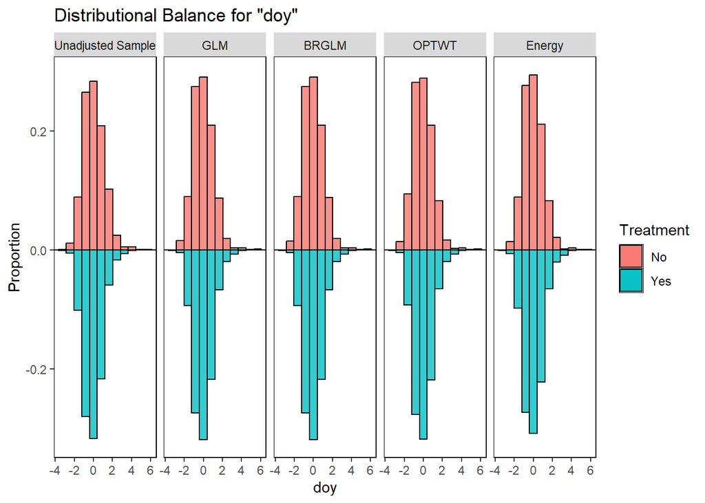

#### 2.2.1.2 `row.space`

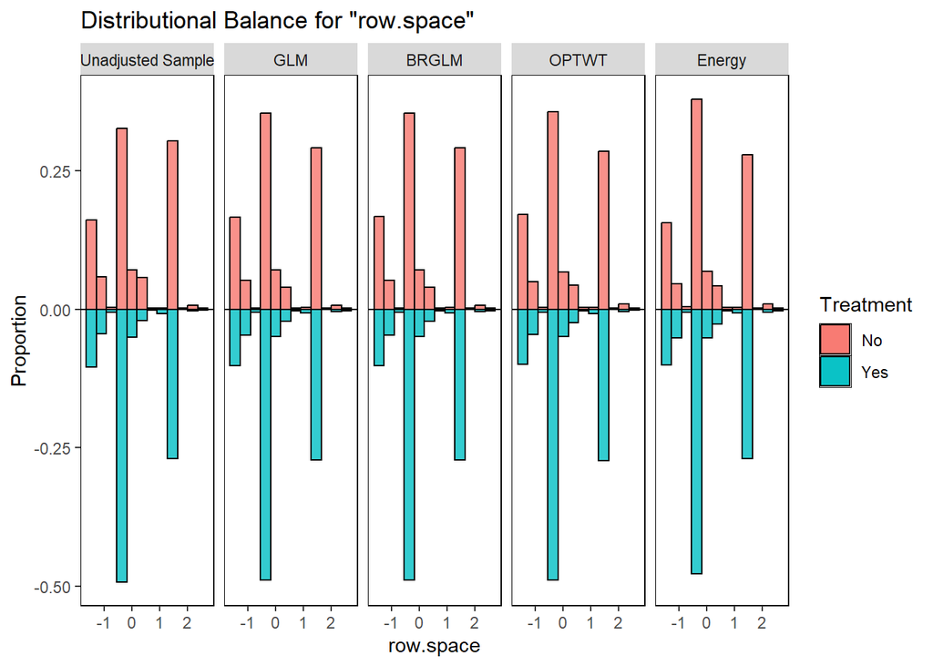

#### 2.2.1.3 `seed.rate`

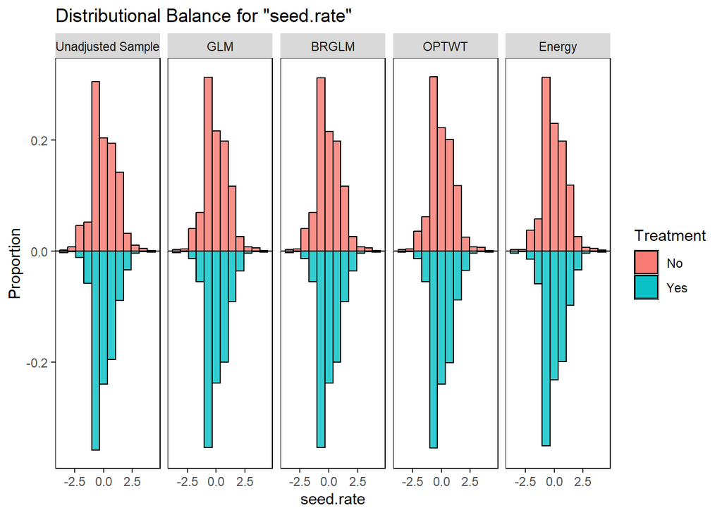

#### 2.2.1.4 `OM.0.30.cm`

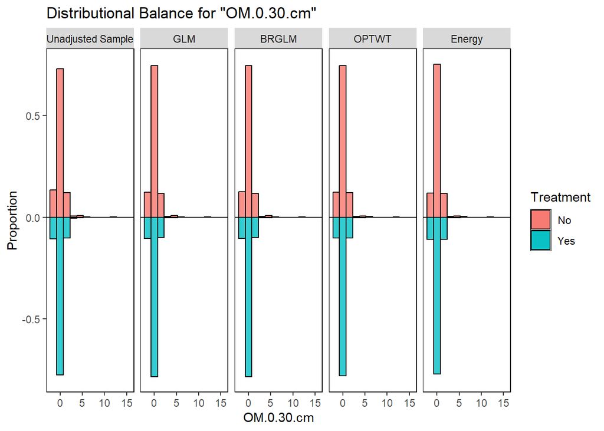

#### 2.2.1.5 `pH.0.30.cm`

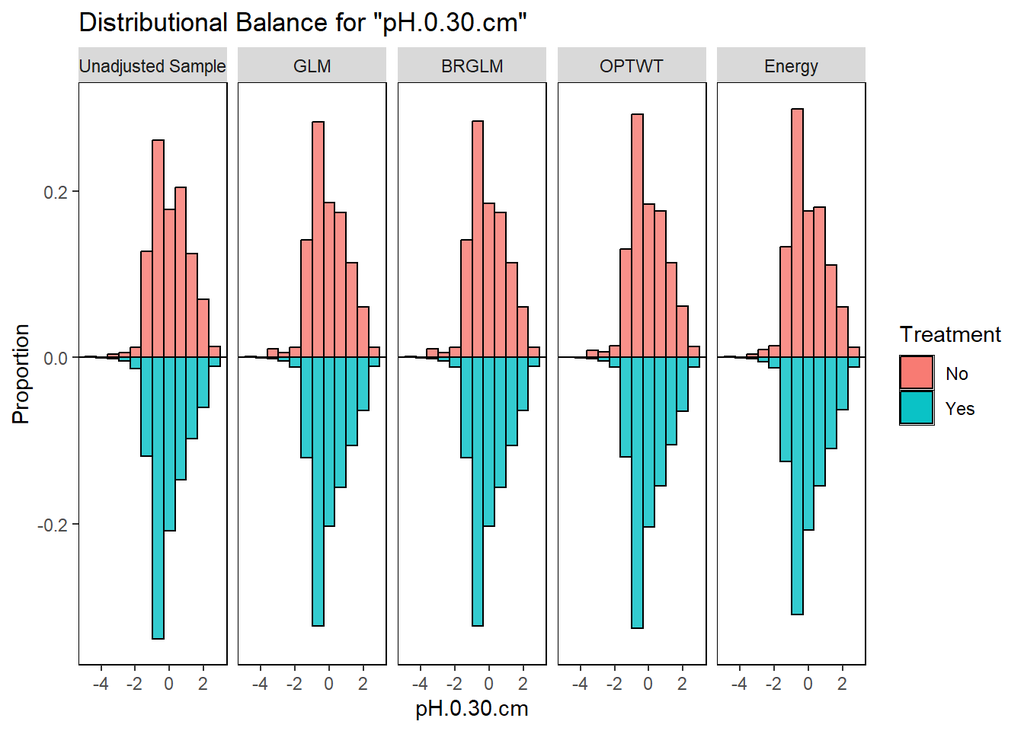

#### 2.2.1.6 `TWI`

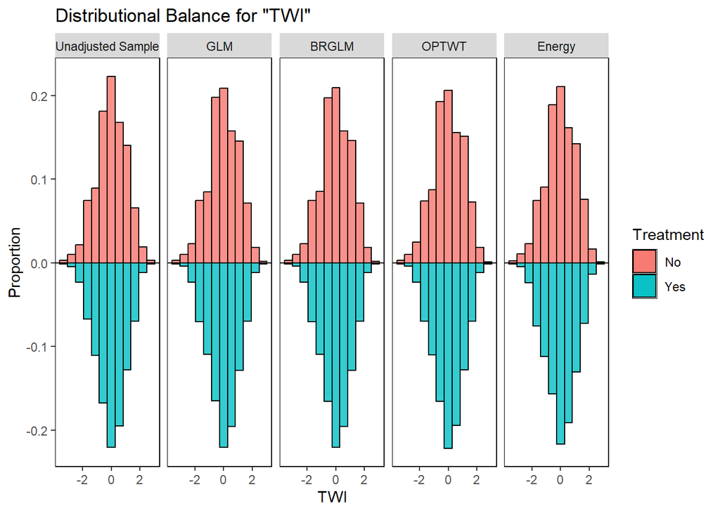

#### 2.2.1.7 `lr.sand`

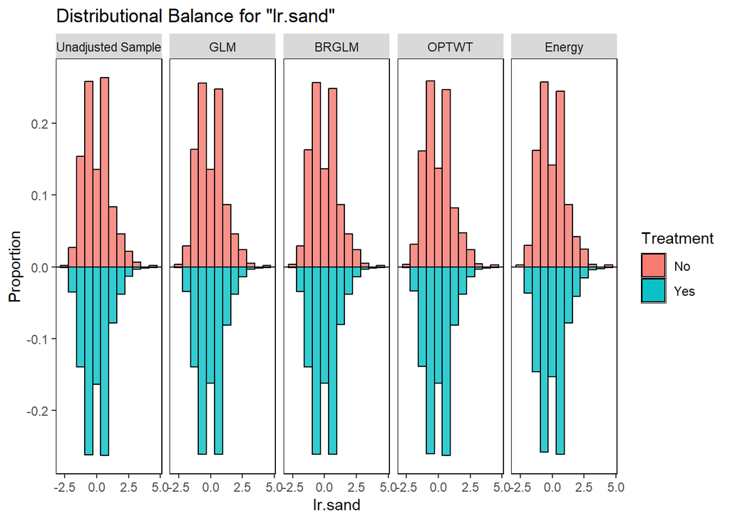

#### 2.2.1.8 `lr.clay`

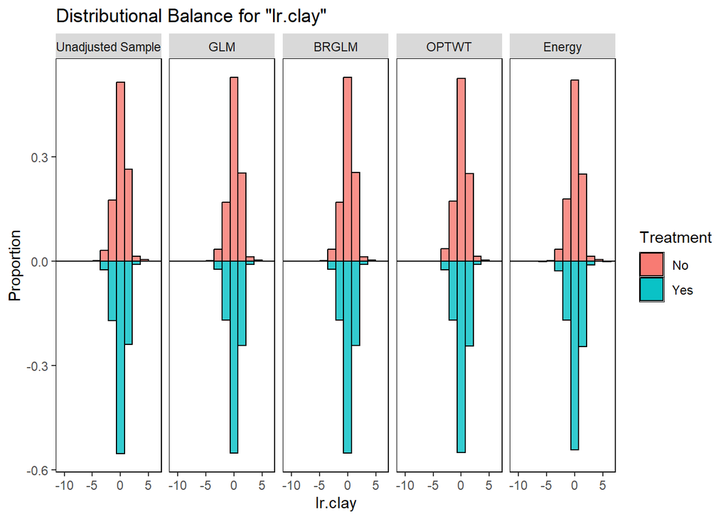

#### 2.2.1.9 `PDtoEmerg`

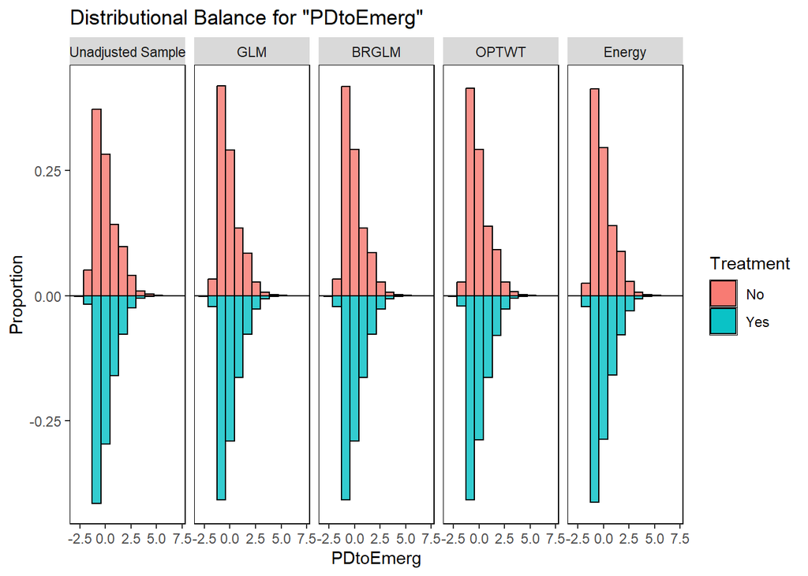

#### 2.2.1.10 `sum.swe.boytopd`

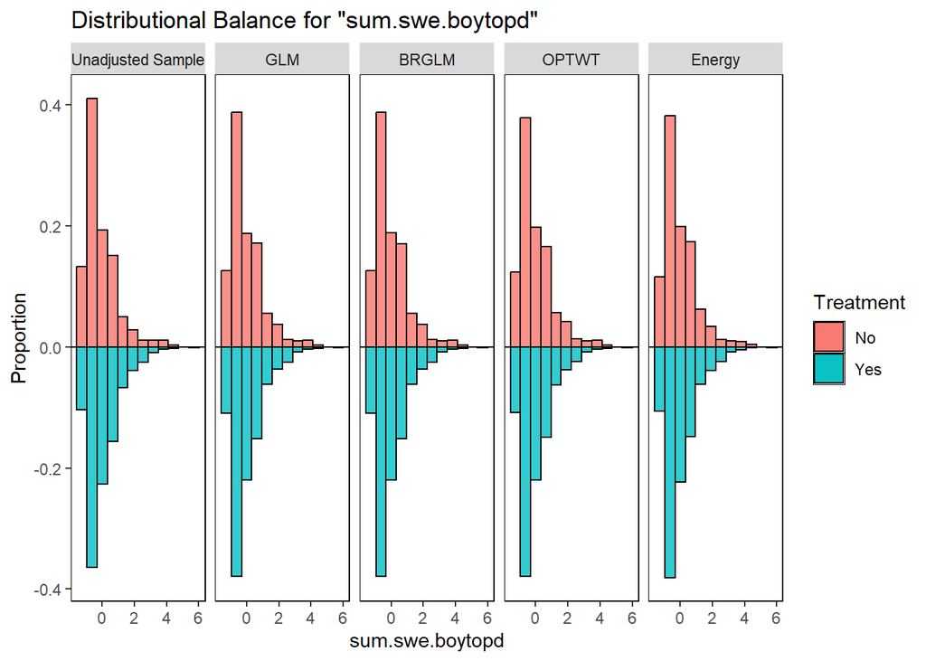

#### 2.2.1.11 `sum.prcp.pdtoemg`

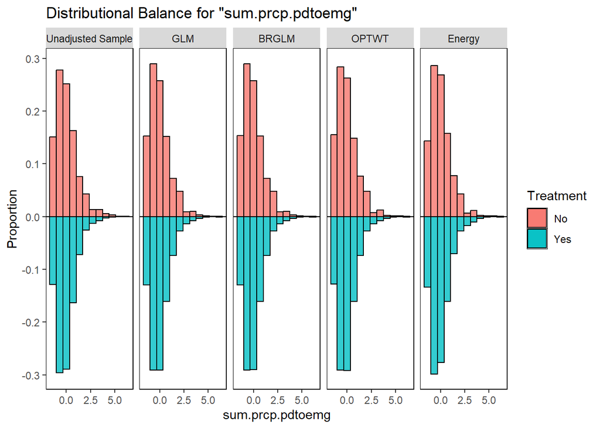

#### 2.2.1.12 `sum.prcp.emgtoR3`

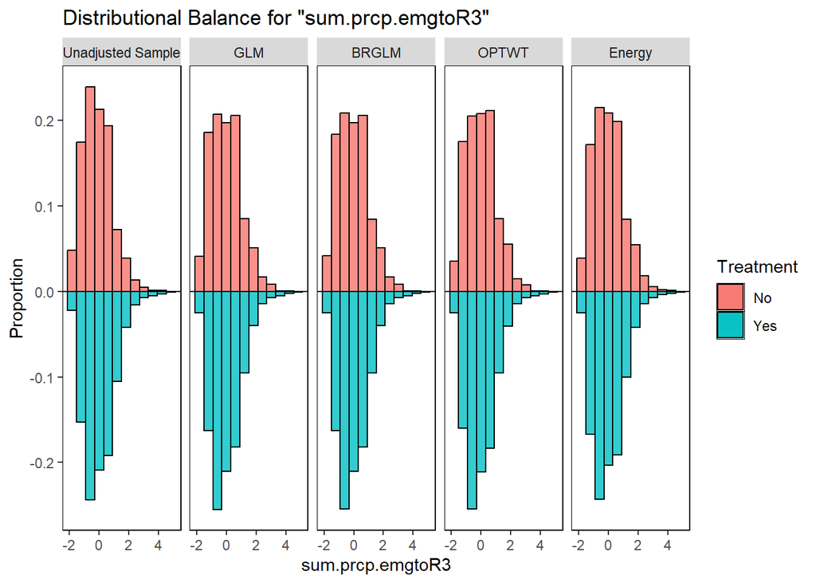

#### 2.2.1.13 `sum.prcp.R3toR7`

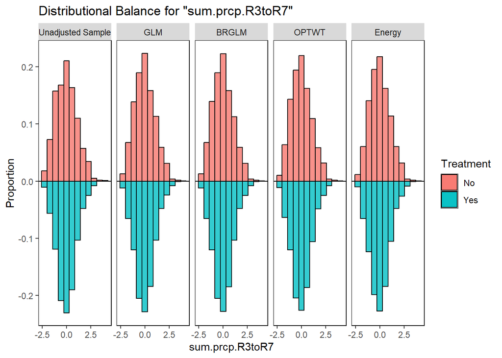

#### 2.2.1.14 `sum.srad.emgtoR3`

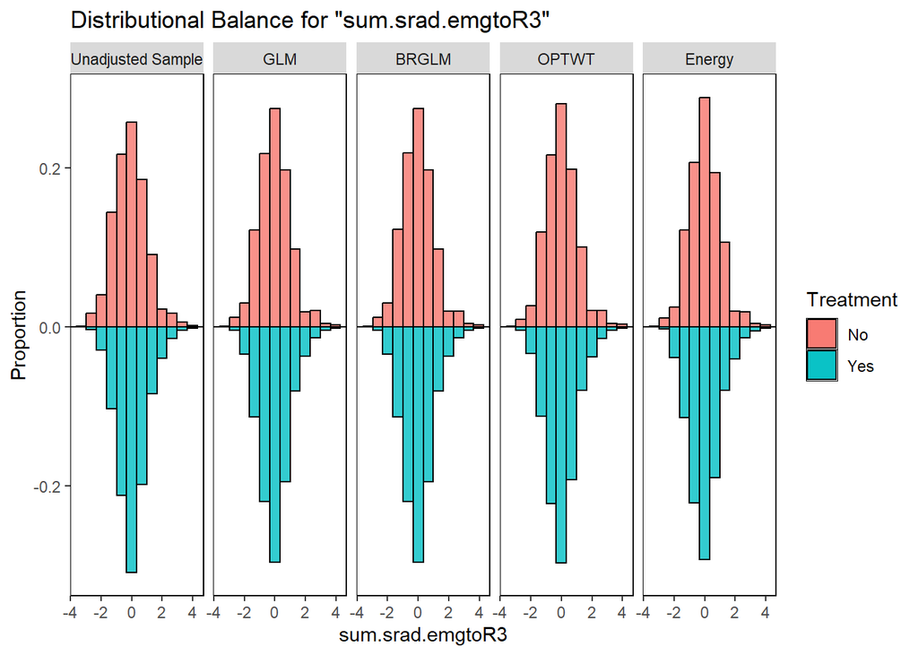

#### 2.2.1.15 `sum.srad.R3toR7`

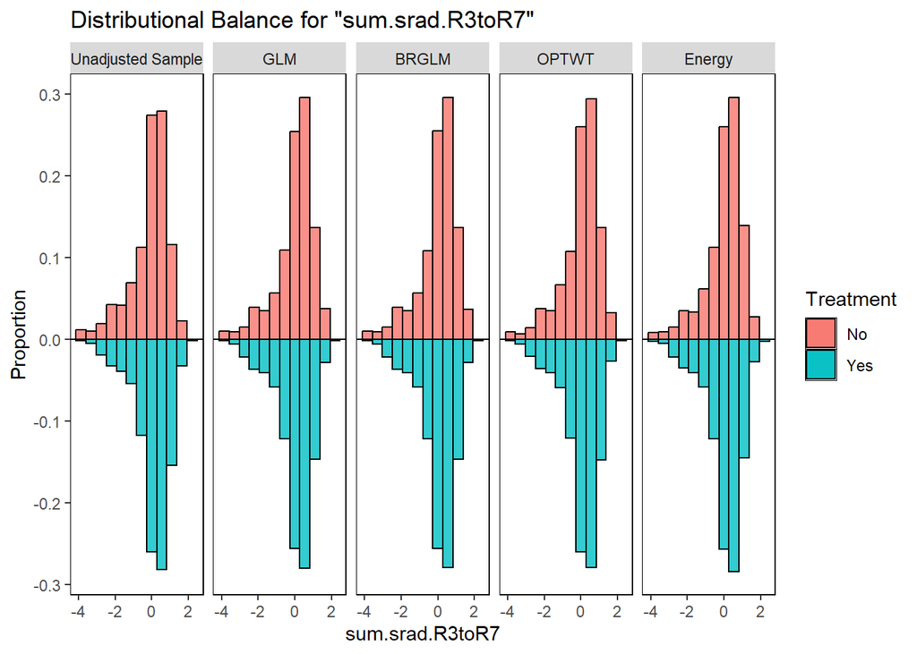

#### 2.2.1.16 `mean.tave.pdtoemg`

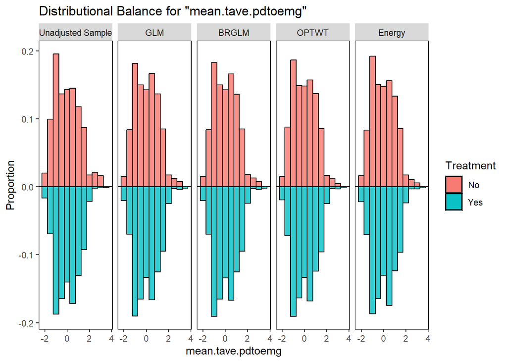

#### 2.2.1.17 `mean.tave.emgtoR3`

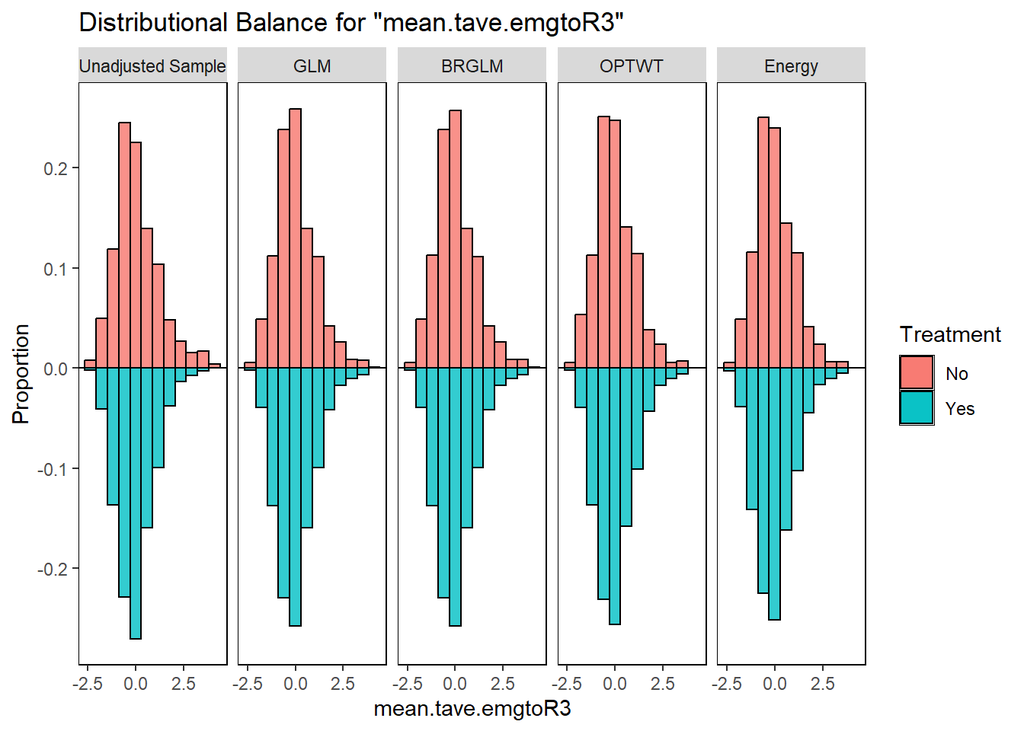

#### 2.2.1.18 `mean.tave.R3toR7`

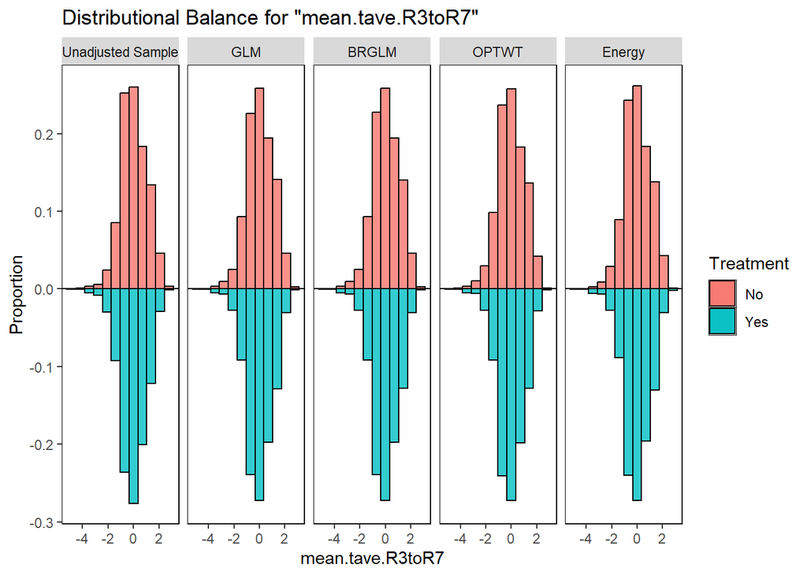

#### 2.2.1.19 `mean.rh.emgtoR3`

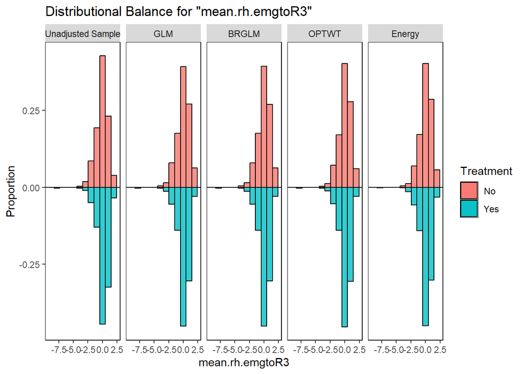

#### 2.2.1.20 `mean.rh.R3toR7`

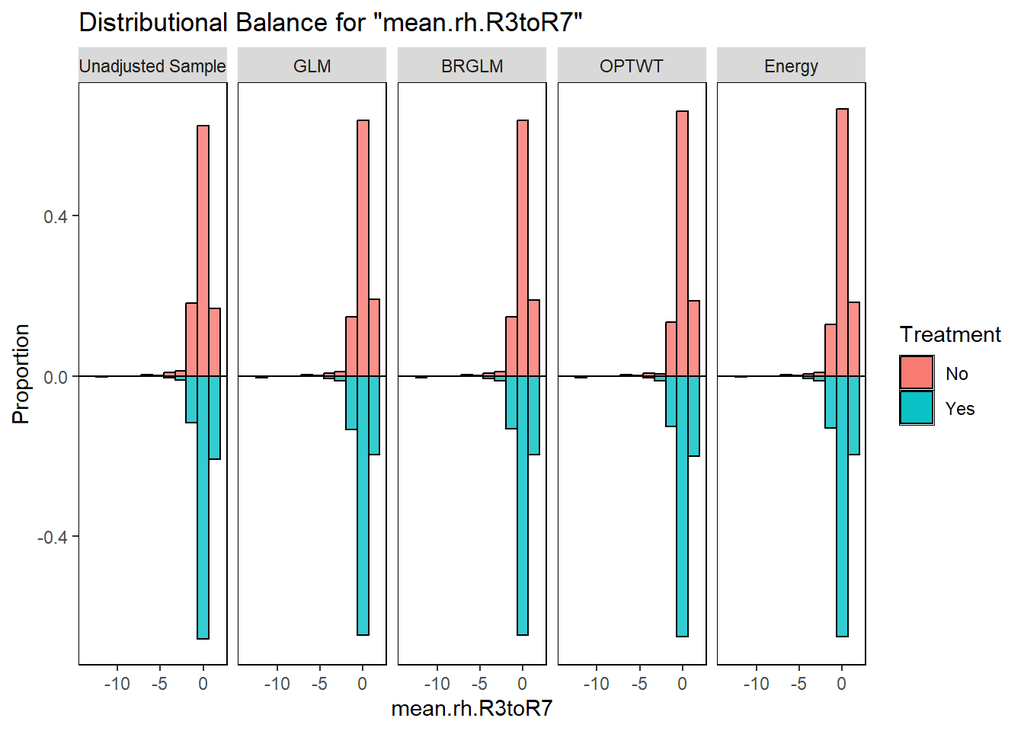

### 2.2.2 Categorical variables

#### 2.2.2.1 `artificial.drainage`

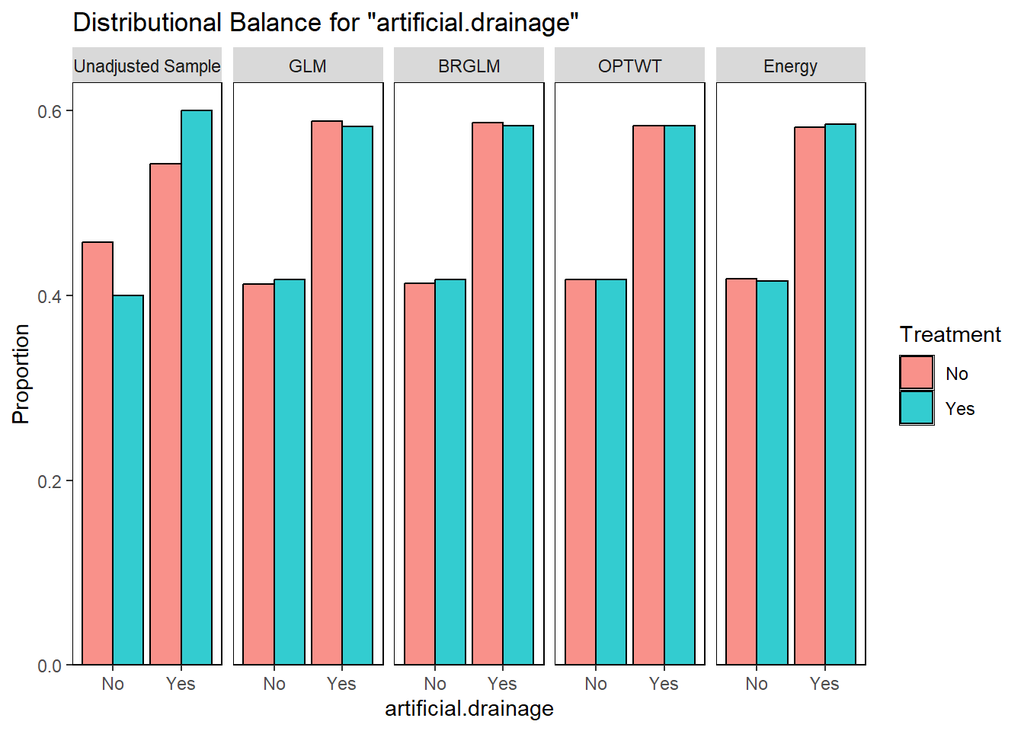

#### 2.2.2.2 `till.type`

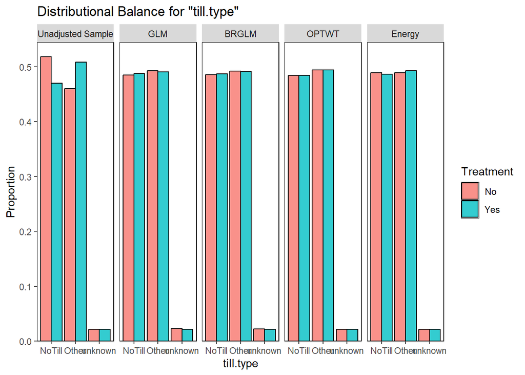

#### 2.2.2.3 `nonstarter.fert`

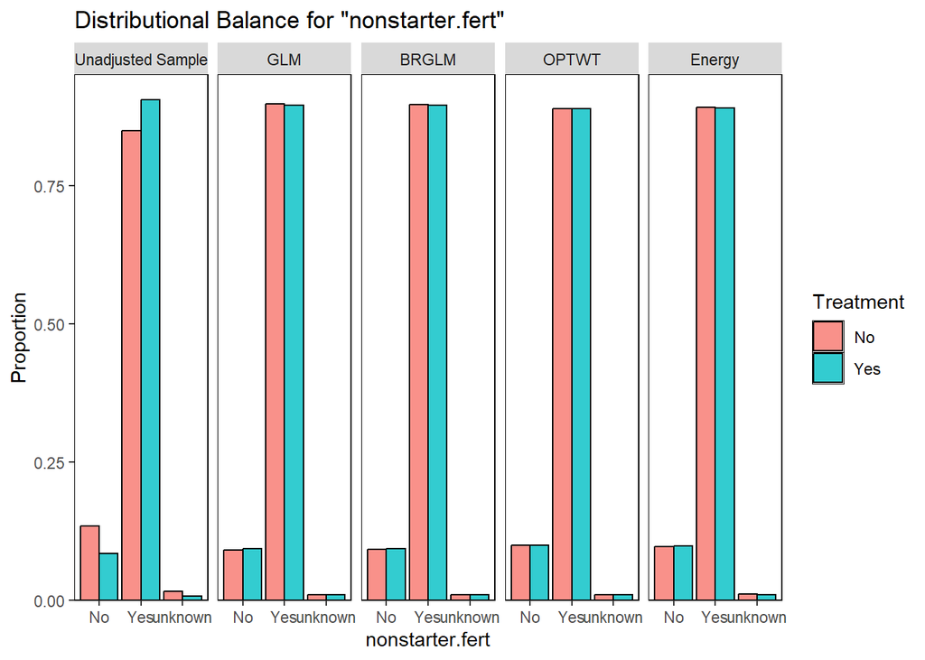

#### 2.2.2.4 `lime`

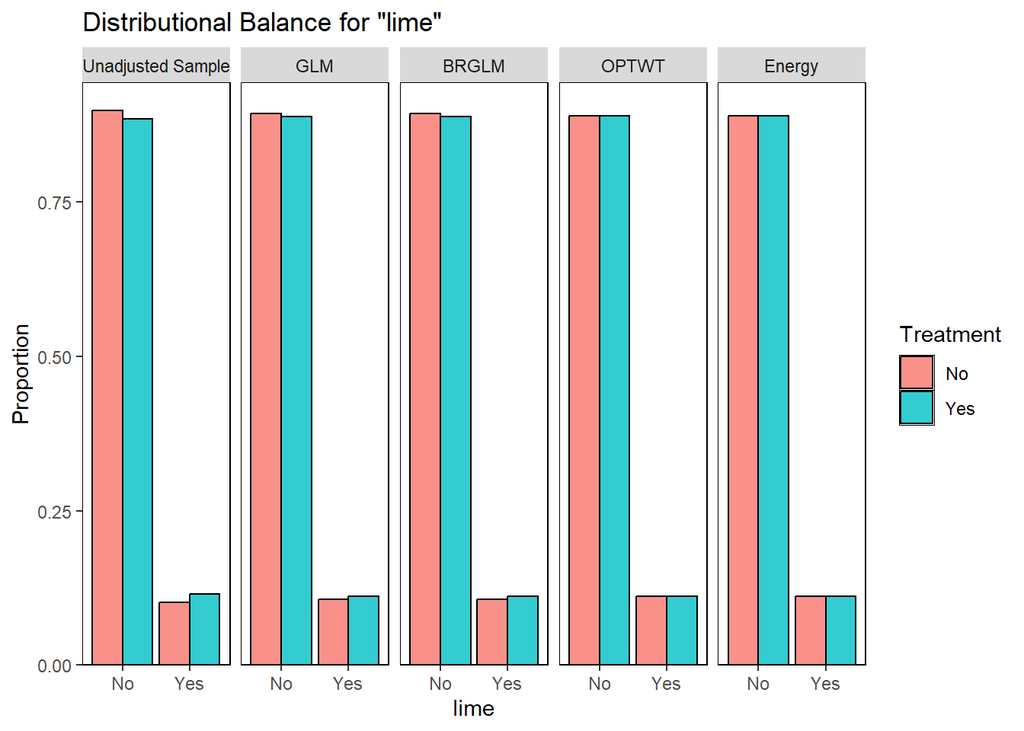

#### 2.2.2.5 `manure`

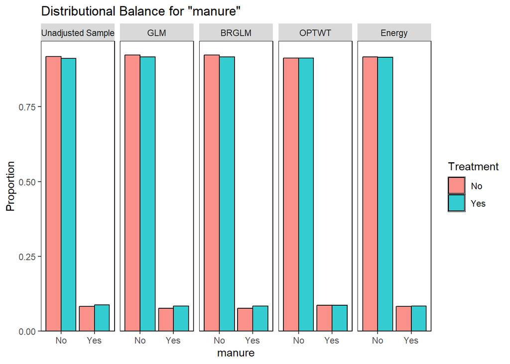

#### 2.2.2.6 `MG`

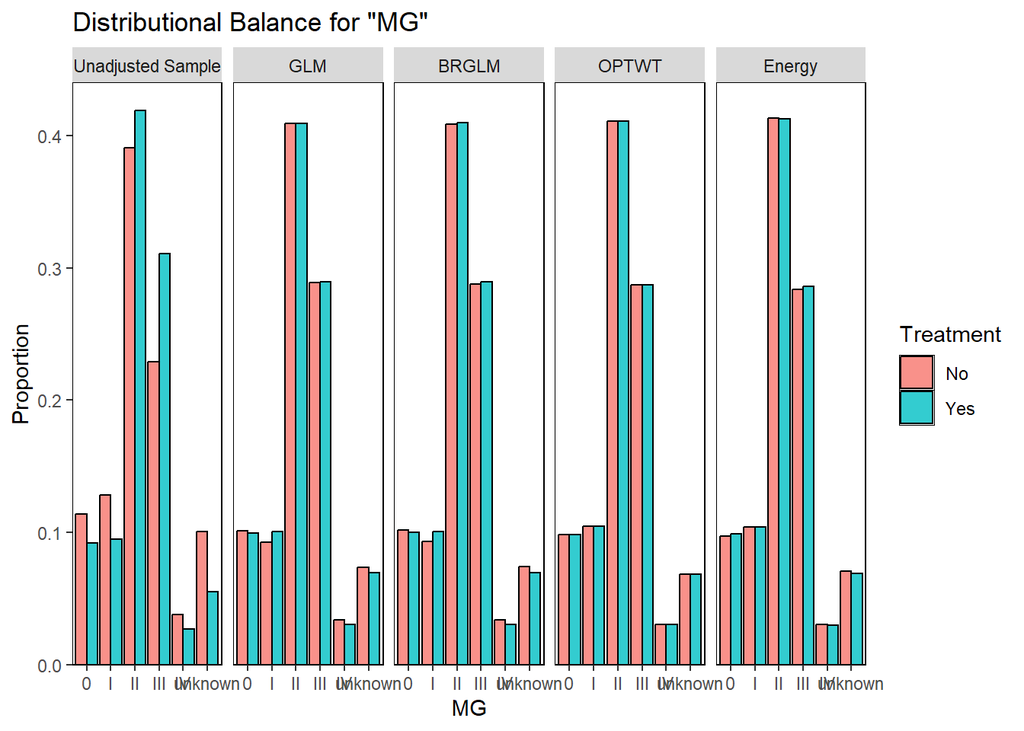

#### 2.2.2.7 `starter.fert`

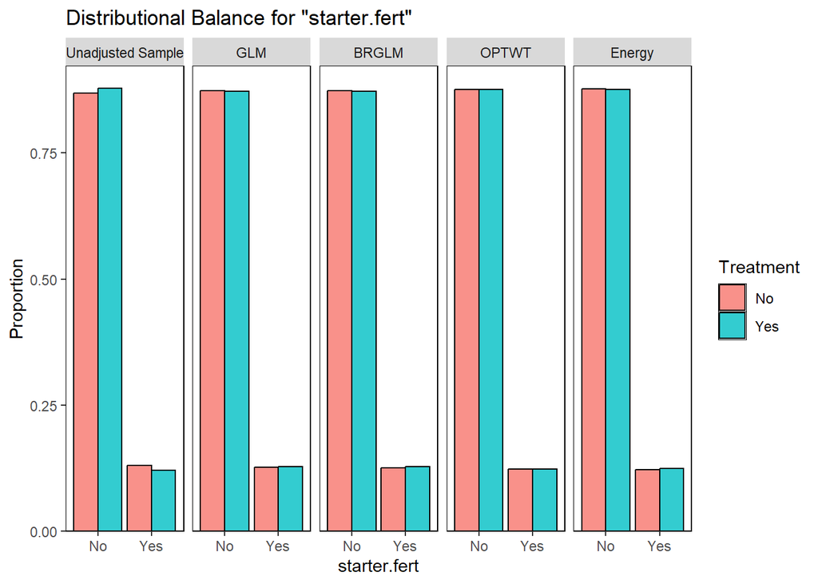

#### 2.2.2.8 `foliar.fungicide`

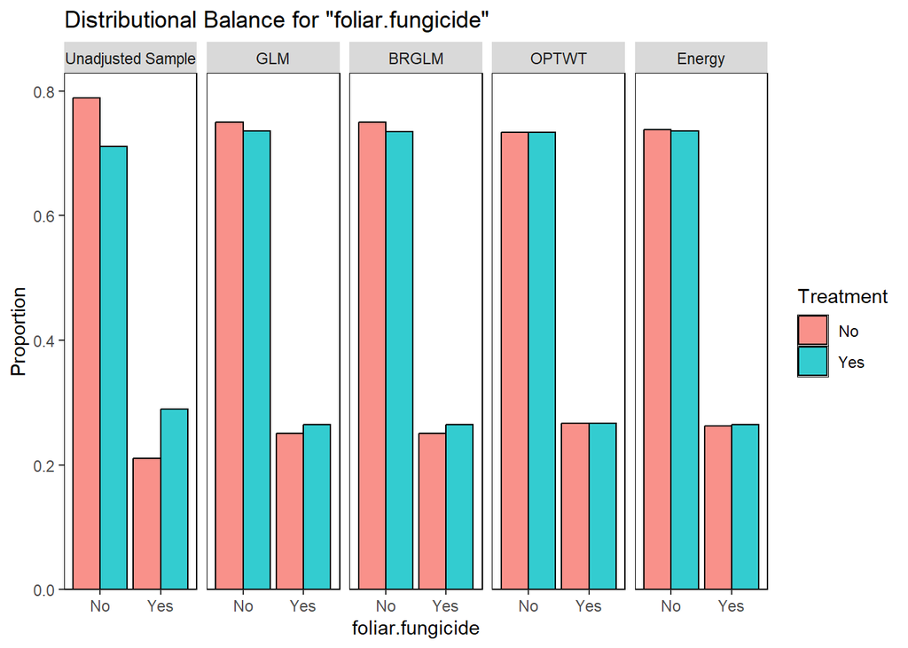

#### 2.2.2.9 `foliar.insecticide`

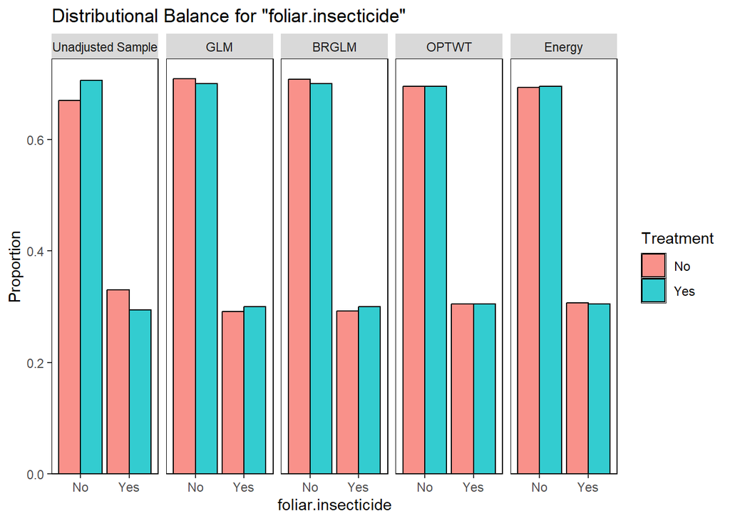

#### 2.2.2.10 `herbicide`

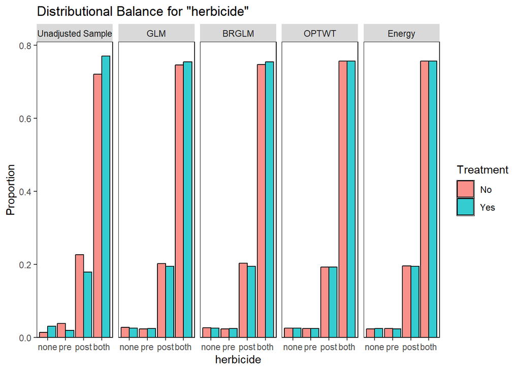

#### 2.2.2.11 `nematodes`

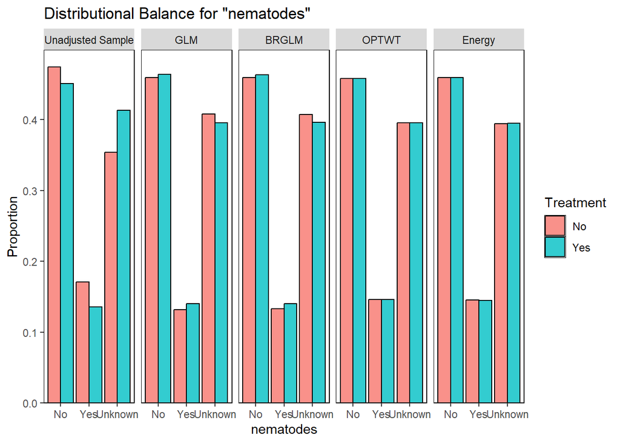

#### 2.2.2.12 `iron.def`

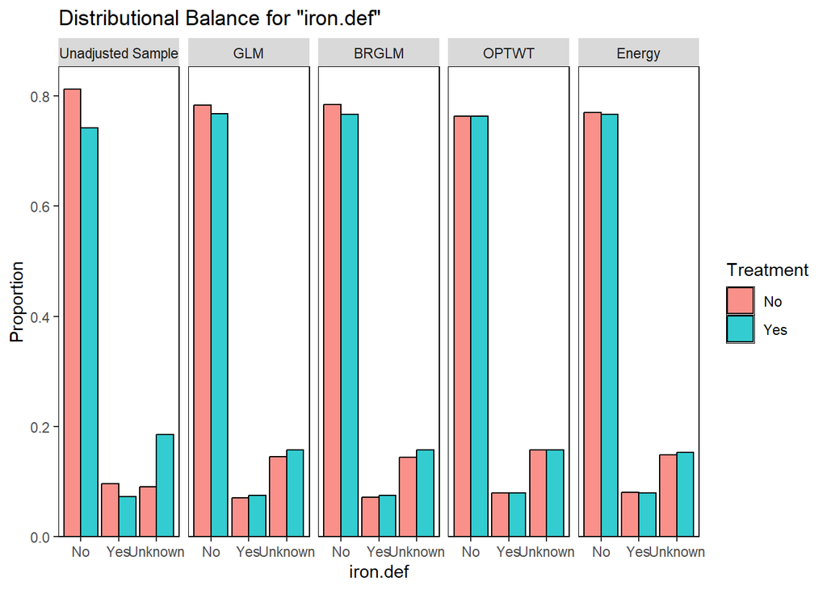